# Внешний курс. Этап №1

Безопасность в сети

Сергеев Даниил Олегович

1132246837@rudn.ru

Российский университет дружбы народов

2026-05-11

# Информация

## Докладчик

- Сергеев Даниил Олегович
- Студент
- Направление: Прикладная информатика
- Российский университет дружбы народов
- 1132246837@pfur.ru
- https://github.com/FrigatZero

# Цель работы

- Изучить основы кибербезопасности;
- Понять, как работает Интернет, и какие у него “слабые” места;
- Уяснить, почему `1245YOURNAME` - плохой пароль;
- Научиться отличать шифрование от электронной подписи;
- Узнать, как работают электронные платежи.

# Задание

- Пройти курс;
- Получить сертификат;
- Записать видео по каждому разделу;
- Записать итоговую презентацию по каждому этапу;
- Написать отчёт по прохождению контрольных мероприятий по каждому разделу.

# Ход выполнения лабораторной работы

Приступим к выполнению первого этапа внешнего курса - Безопасности в сети.

## Как работает интернет: базовые сетевые протоколы

1. UDP и TCP - протоколы транспортного уровня, а IP - протокол сетевого уровня, поэтому выбираем HTTPS.

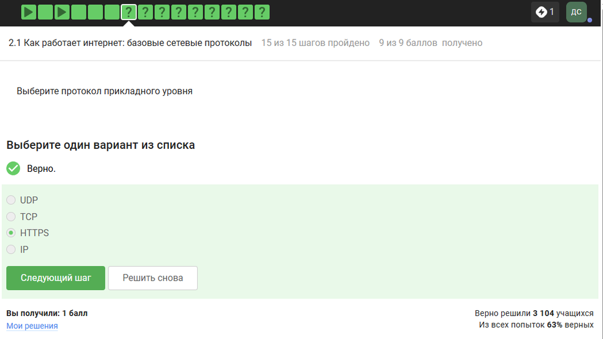

Задание №1. Условие и ответ

## Как работает интернет: базовые сетевые протоколы

2. Протокол TCP работает на транспортном уровне и отвечает за надёжную доставку пакетов.

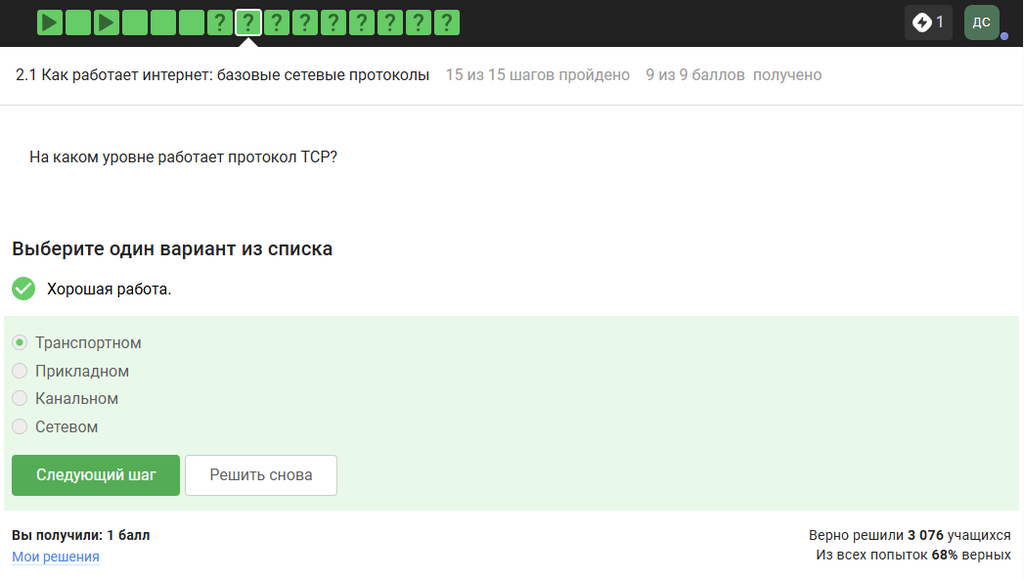

Задание №2. Условие и ответ

## Как работает интернет: базовые сетевые протоколы

3. Каждое число в IPv4 должно быть от 0 до 255. Адреса с 256 или 421 содержат недопустимые значения.

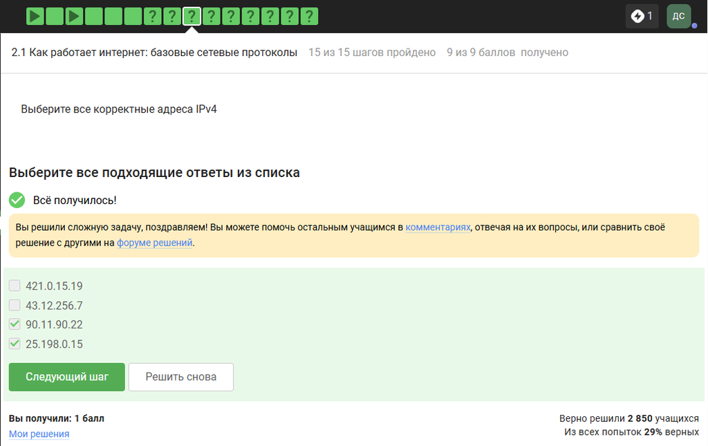

Задание №3. Условие и ответ

## Как работает интернет: базовые сетевые протоколы

4. DNS (Domain Naming System) - система для распознования IP-адресов серверов по их доменному имени. Она сопоставляет каждому домену его адрес, перенаправляя пакет на нужный узел.

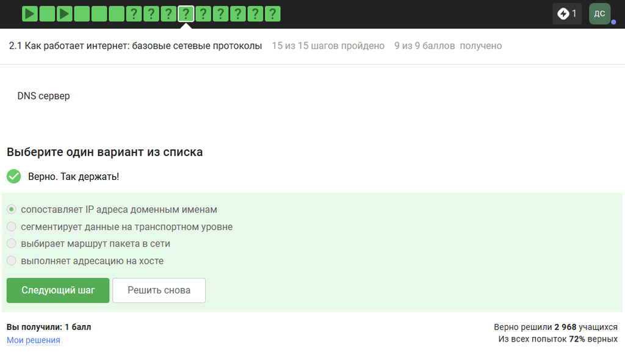

Задание №4. Условие и ответ

## Как работает интернет: базовые сетевые протоколы

5. В протоколе TCP/IP канальный и физический уровни объединены в один общий уровень (в канальный), как и сеансовый, представительский и прикладной (в прикладной). Четвертый вариант ответа верный.

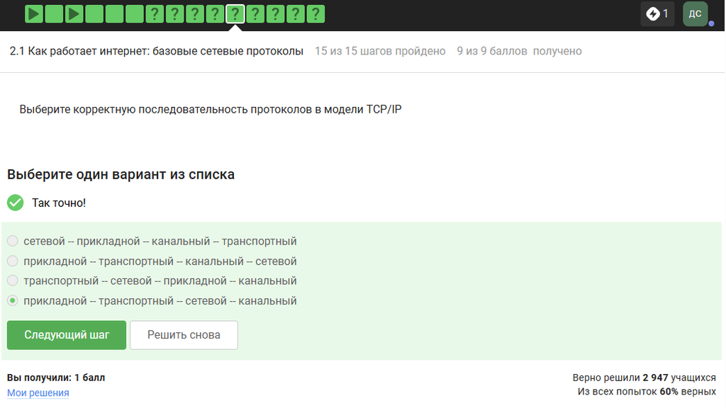

Задание №5. Условие и ответ

## Как работает интернет: базовые сетевые протоколы

6. Протокол HTTP не шифрует трафик, в отличие от HTTPS, что делает пакеты уязвимыми. Выбираем второй вариант.

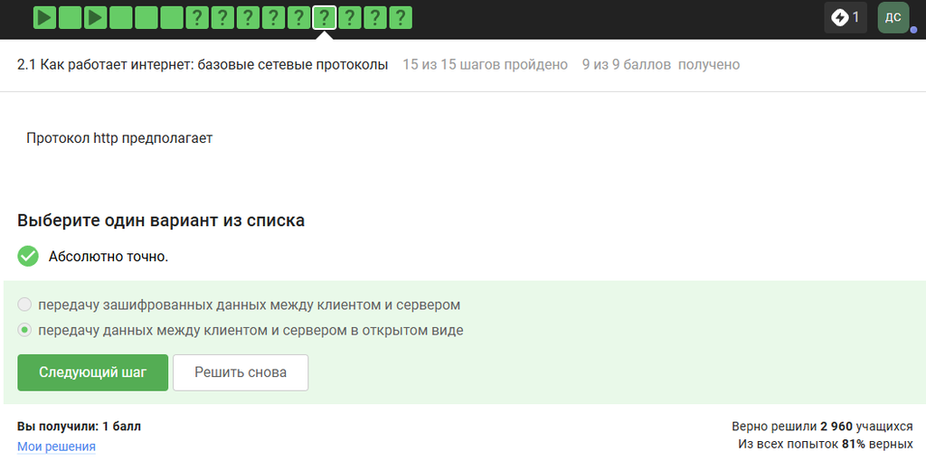

Задание №6. Условие и ответ

## Как работает интернет: базовые сетевые протоколы

7. Протокол HTTPS состоит из двух фаз: рукопожатия (установление безопасного зашифрованного соединения между клиентом и сервером по протоколу TLS) и передача зашифрованных данных.

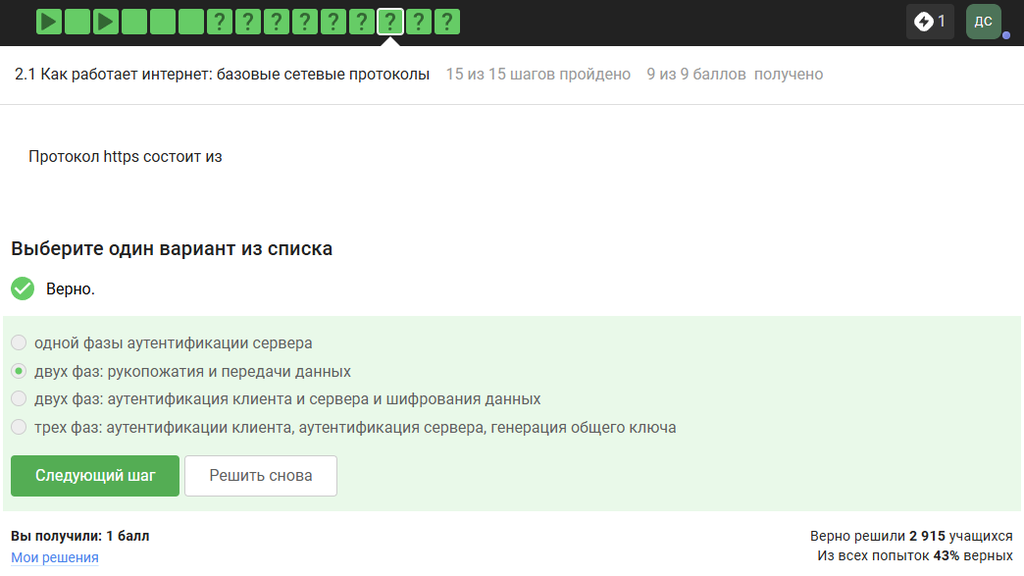

Задание №7. Условие и ответ

## Как работает интернет: базовые сетевые протоколы

8. Во время фазы рукопожатия сервер и клиент согласуют версию протокола TLS, проводят аутентификацию и проверяют целостность соединения.

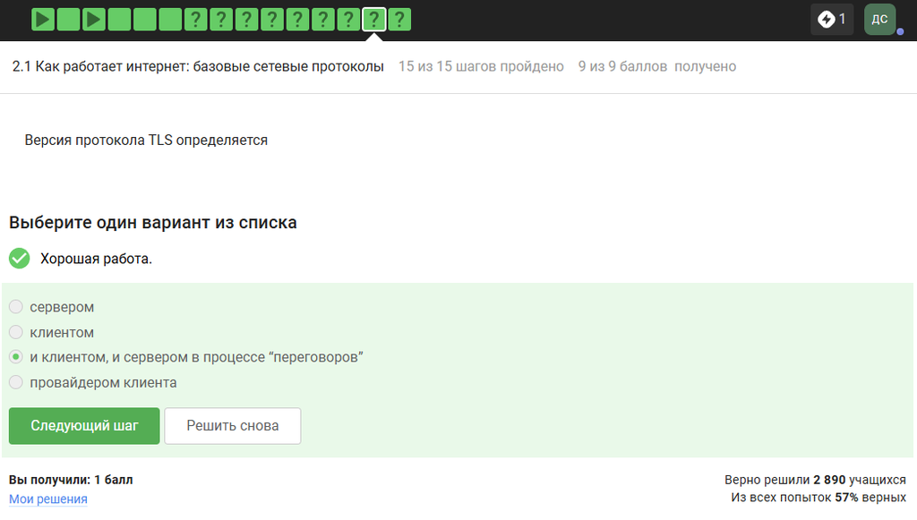

Задание №8. Условие и ответ

## Как работает интернет: базовые сетевые протоколы

9. Шифрование TLS начинается после завершения рукопожатия, а до этого только выбираются алгоритмы совместного шифрования.

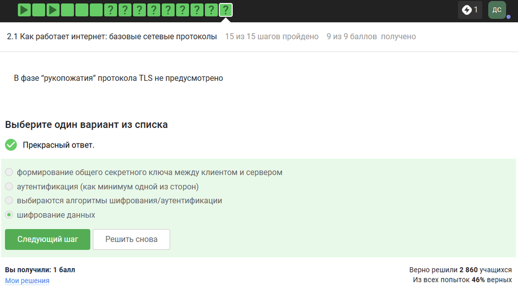

Задание №9. Условие и ответ

## Персонализация сети

1. Куки используются для хранения идентификатора сессии. IP-адрес и пароль напрямую в куки не помещают, а идентификатор пользователя не всегда присутствует, но допустим.

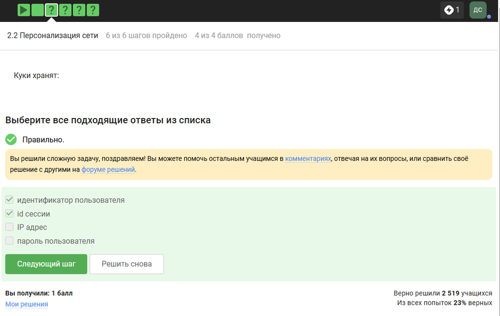

Задание №10. Условие и ответ

## Персонализация сети

2. Куки сохраняют состояние сессии и используются для персонализации, но не влияют на надёжность сетевого соединения.

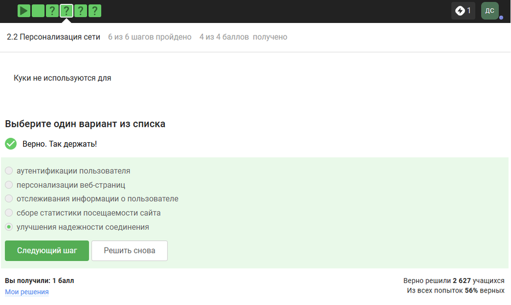

Задание №11. Условие и ответ

## Персонализация сети

3. Веб-сервер генерирует куки для распознования активной сессии и передаёт их браузеру с помощью заголовка для дальнейшего использования.

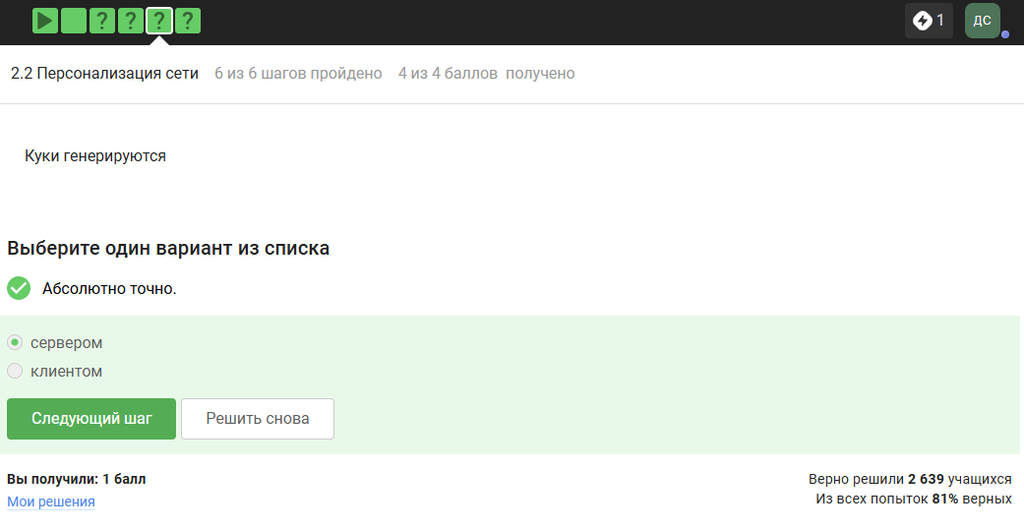

Задание №12. Условие и ответ

## Персонализация сети

4. Сессионные куки удаляются после закрытия браузера и не имеют фиксированного срока хранения. Постоянные куки предназначены для долгосрочного хранения данных о действиях на сайте.

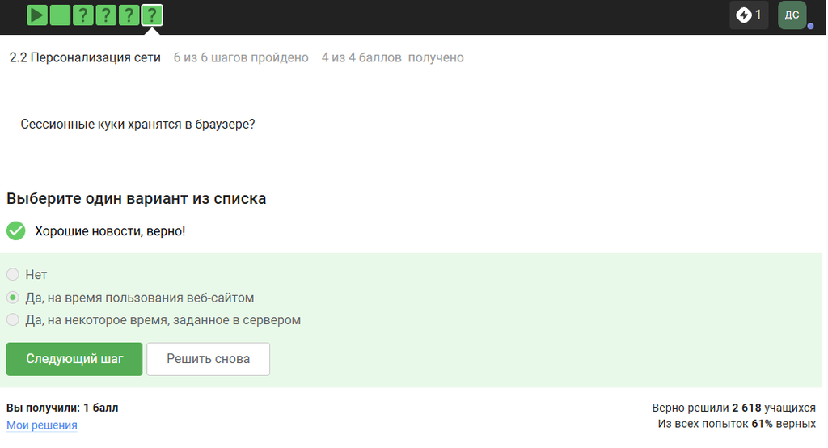

Задание №13. Условие и ответ

## Браузер TOR. Анонимизация

1. Обычно весь трафик в TOR передаётся минимум через три узла: охранный, промежуточный и выходной. Если же говорить именно о промежуточных узлах, то их может быть от одного и более. Выберем больее общий вариант.

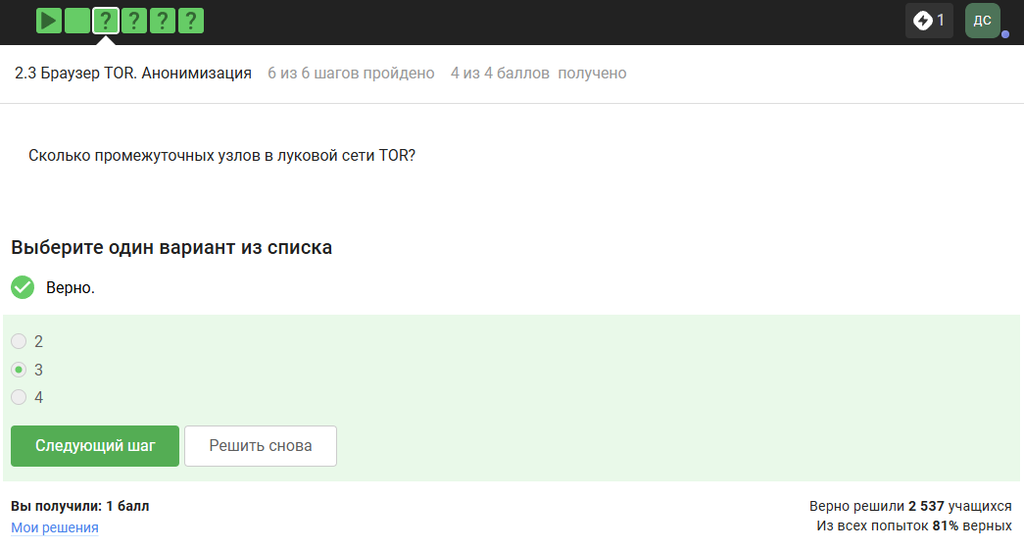

Задание №14. Условие и ответ

## Браузер TOR. Анонимизация

2. Отправитель знает адрес, чтобы инициировать передачу через охранный узел, также выходной узел соединяется с целевым сервером от своего имени. Охранный и средний узлы видят только следующий узел цепочки, адрес получателя им не известен.

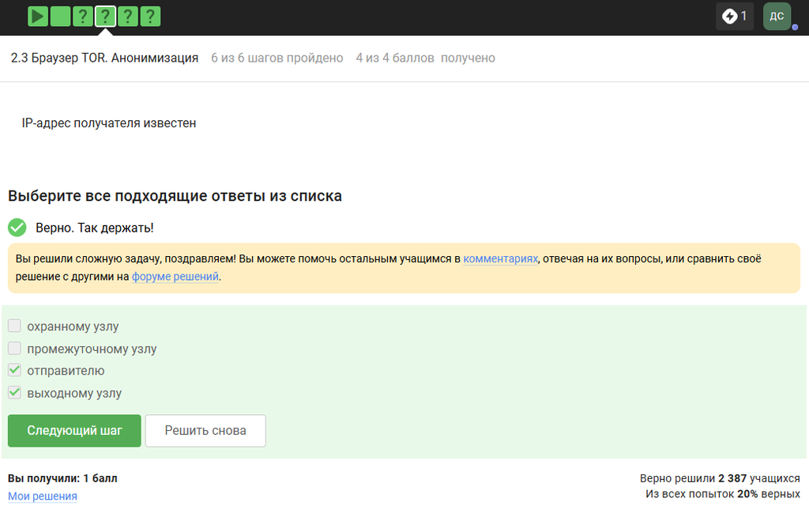

Задание №15. Условие и ответ

## Браузер TOR. Анонимизация

3. Общие секретные ключи последовательно согласовываются с каждым узлом (охранным, промежуточным и выходным) для послойного шифрования (луковая маршрутизация). Выбираем все узлы.

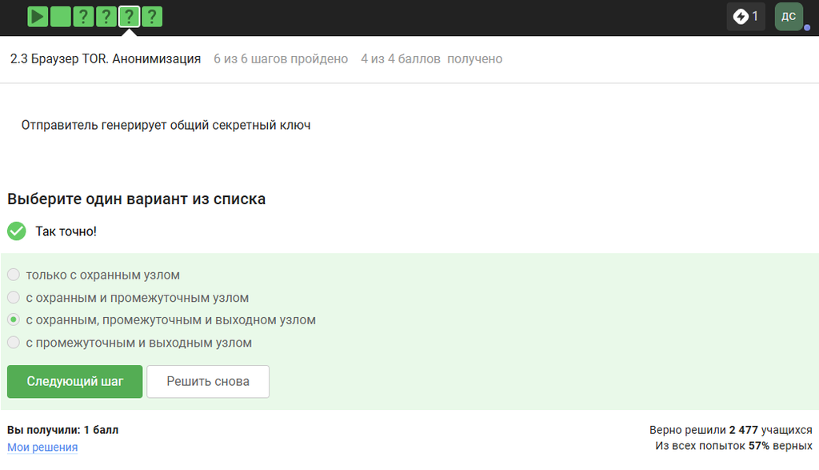

Задание №16. Условие и ответ

## Браузер TOR. Анонимизация

4. TOR скрывает клиента, из-за чего сервер-получатель общается с выходным узлом по обычному интернет-протоколу без установки TOR.

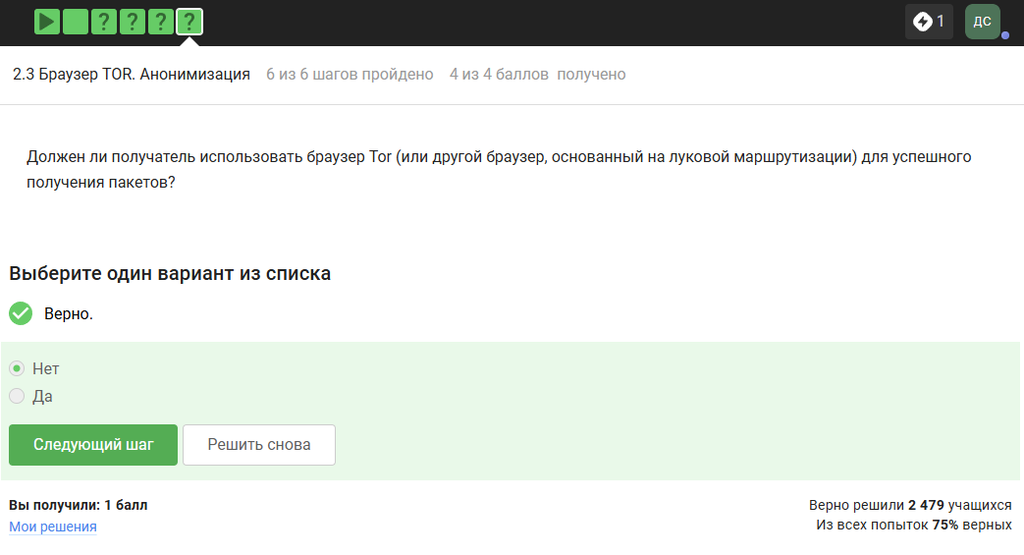

Задание №17. Условие и ответ

## Беспроводные сети Wi-Fi

1. Wi-Fi - это технология по реализации беспроводной передачи данных по радиоканалу при помощи семейства стандартов IEEE 802.11.

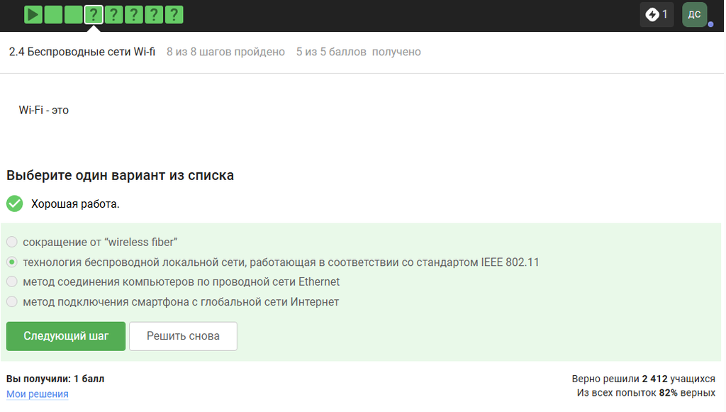

Задание №18. Условие и ответ

## Беспроводные сети Wi-Fi

2. Wi-Fi описывает доступ к среде и кадровую передачу, что соответствует канальному уровню модели TCP/IP.

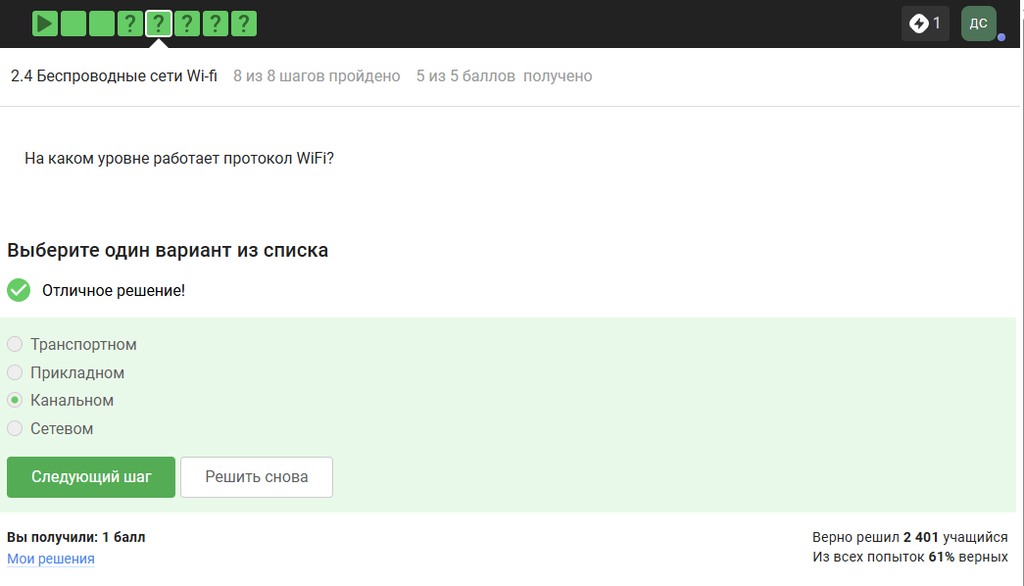

Задание №19. Условие и ответ

## Беспроводные сети Wi-Fi

3. WEP содержит криптографические уязвимости (например, статический ключ шифрования) и был заменён на WPA/2/3.

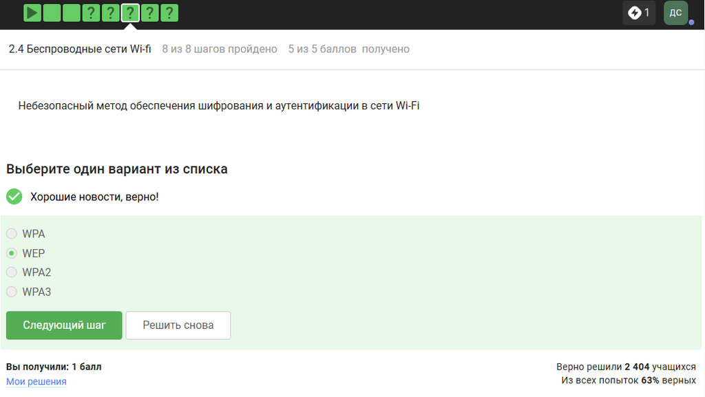

Задание №20. Условие и ответ

## Беспроводные сети Wi-Fi

4. После успешной аутентификации и согласования ключей трафик шифруется, иначе не было бы смысла в самом процессе аутентификации.

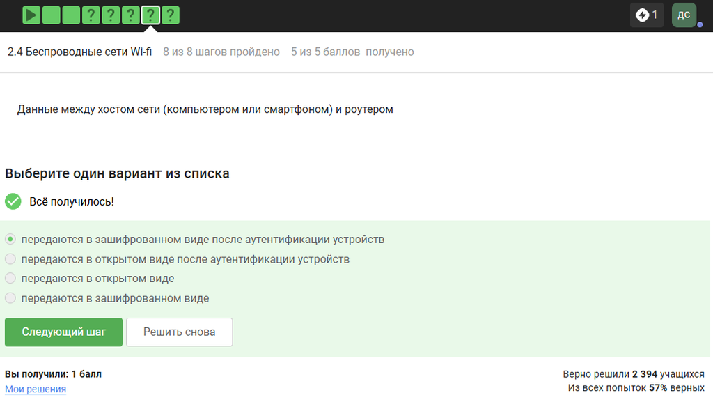

Задание №21. Условие и ответ

## Беспроводные сети Wi-Fi

5. Для домашней сети обычно используют WPA2 Personal. Этот метод использует общий пароль для каждого пользователя, без инфраструктуры серверов аутентификации.

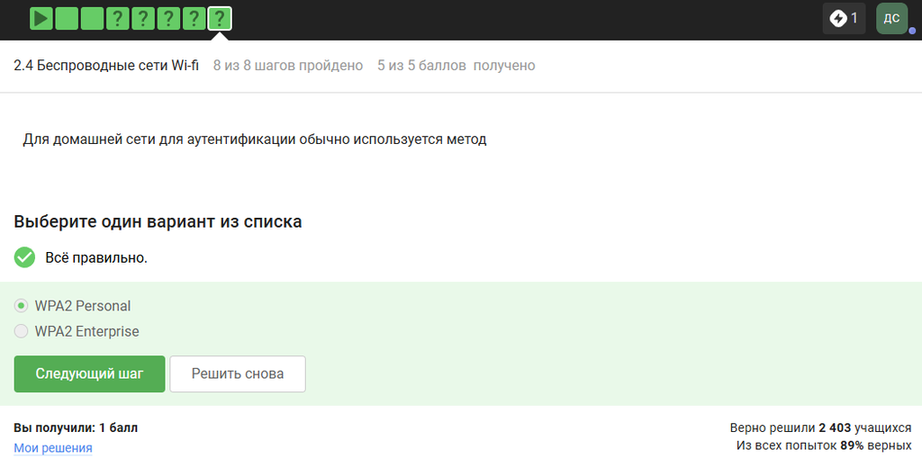

Задание №22. Условие и ответ

# Вывод

В результате выполнения первого этапа внешнего курса я узнал о базовых протоколах пердачи информации по моделям ISO и TCP/IP, а также изучил на базовом уровне как устроена персонализация сети, браузер анонимной пересылки пакетов Tor и технология беспроводной передачи Wi-Fi.